# On the Relation Between the History of Changes and Bugs

#### RQ3: Which kind of changes are mostlyrelated to the bugs insertion?

Explicar os gráficas de maneira mais profunda. Ex: Explicar porque o elastich-search tem mais remoção de metricas do que adição. Explicar esse tipo de comportamento também em relação as metricas no demais gráficos. (Biel)

Plotar gráficos com ranking individuais utilizando o Gráfico de pareto em cima de cada uma das metricas; Dependendo dos resultados retirar os gráficos de grupos ou métricas devido a redundância apresentada no paper (Problema de agrupamento descrito pelo Leonardo)

- Gráfico de Pareto de Metricas Individuais

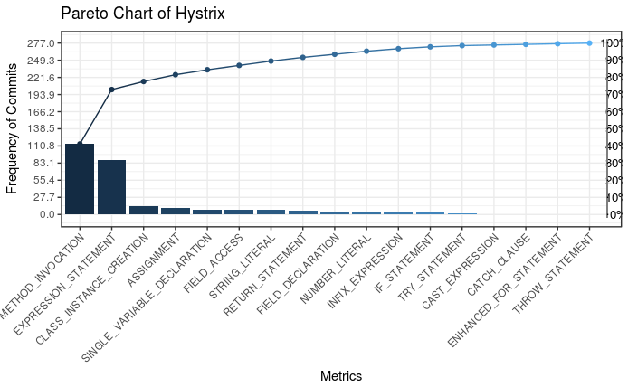

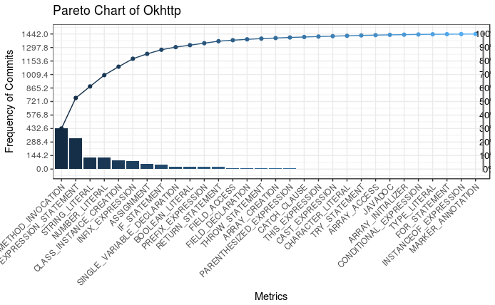

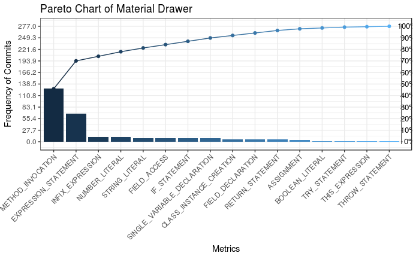

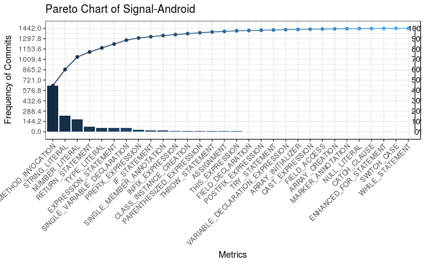

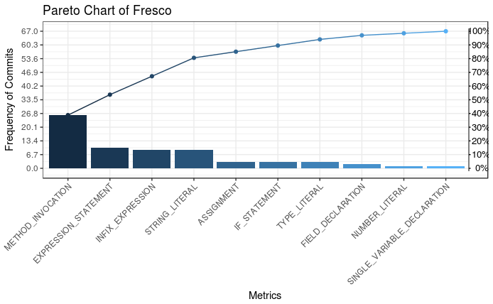

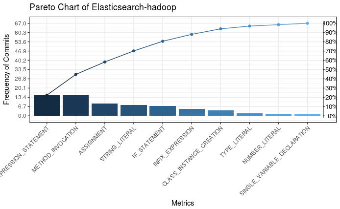

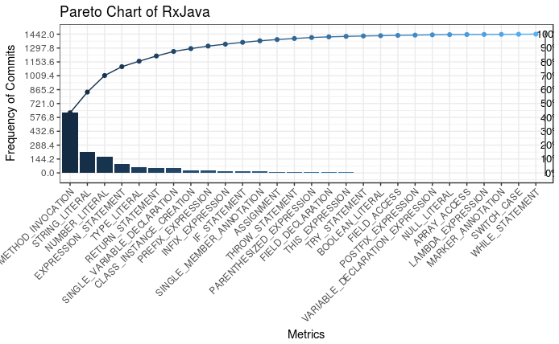

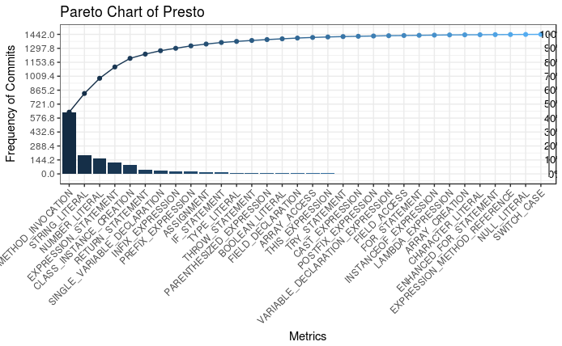

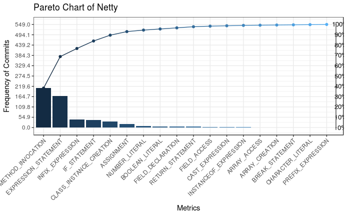

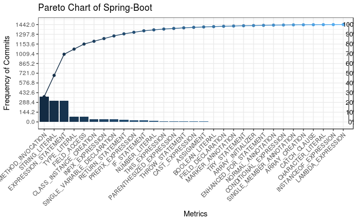

```r
#IndividualMetrics
indMetrics <- read.csv(file = "~/R/analysis/methods/dataMetricsGranger.csv", stringsAsFactors = FALSE)
# Transpose the data frame
#indMetrics <- t(indMetrics[,1:ncol(indMetrics)])
# Set the column headings from the first column in the original table
#colnames(indMetrics) <- indMetrics[1,]
#pareto.chart(indMetrics, ylab = "Frequency", ylab2 = "Cumulative Percentage", xlab = "Presto",
#cumperc = seq(0, 100, by = 25), main = "Pareto Chart",  plot = TRUE)
# Applying the function to the pareto function:
mylist <- ""
for (project in projects){
  df <- filter(indMetrics, Project == project)[,c(3,4)]
  i<-1
  for (x in 1:nrow(df)){
    for (y in 1:df$Changes[x]){
      mylist[i] <- df$Metric[x]
      i <- i + 1
    }
  }
  ggpareto(mylist, project, "Metrics")
}
```

- Gráfico de Pareto de Metricas Agrupadas:

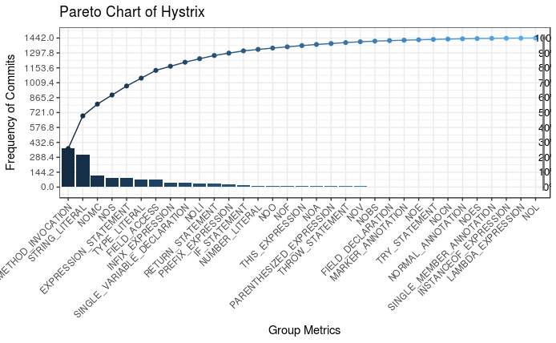

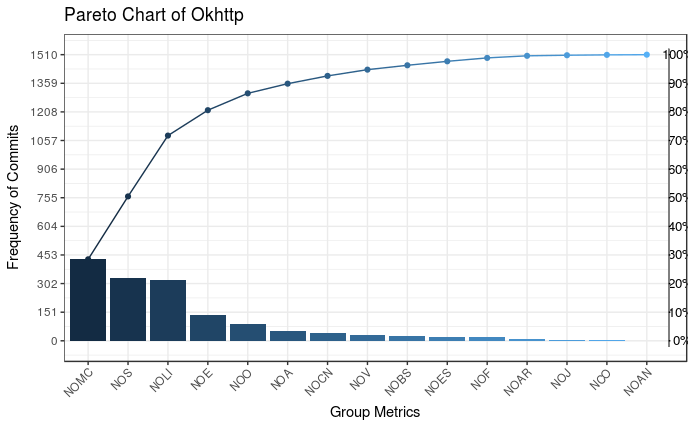

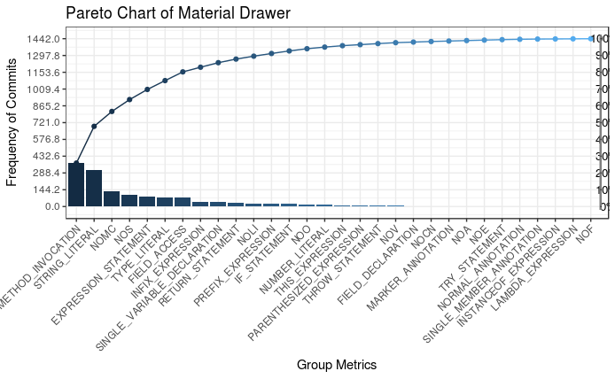

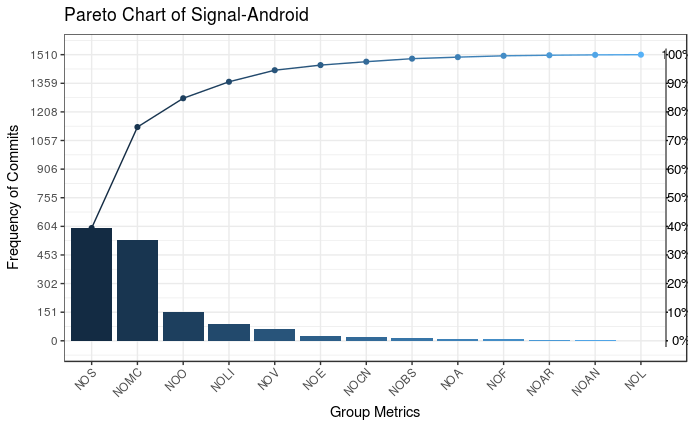

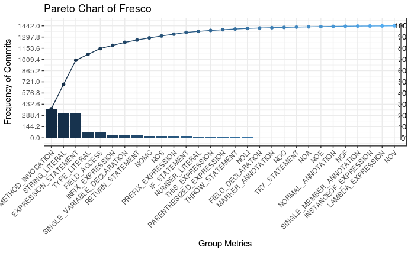

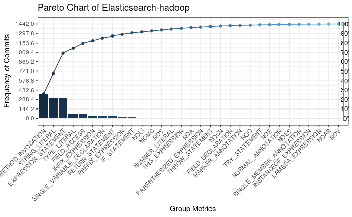

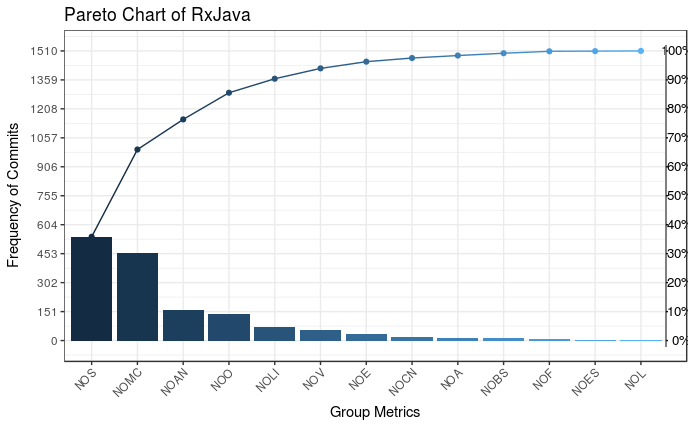

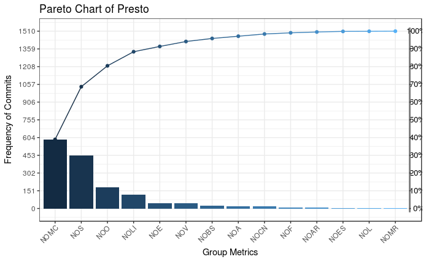

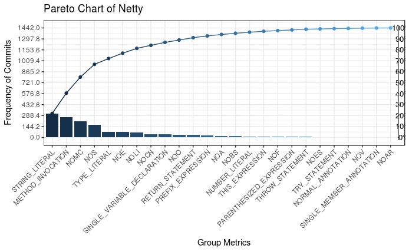

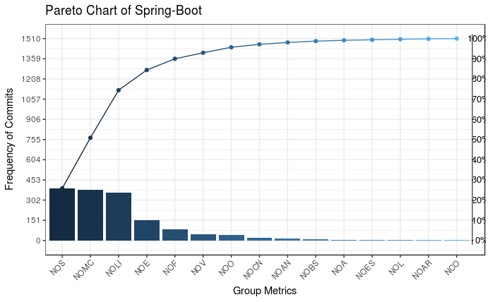

```r
#Groups metrics
grpMetrics <- read.csv(file = "~/R/analysis/methods/dataGroupsGranger.csv", stringsAsFactors = FALSE)
# Applying the function to the pareto function:
for (project in projects){
  df <- filter(grpMetrics, Project == project)[,c(3,4)]
  i<-1
  for (x in 1:nrow(df)){
    for (y in 1:df$Changes[x]){
      mylist[i] <- df$groupMetric[x]
      i <- i + 1
    }
  }
  ggpareto(mylist, project, "Group Metrics")
}
```

### RQ4:

Sair um pouco de predição e tentar analisar o histórico do software, ou seja, seu comportamente ao longo do tempo. Não somente analisar a efeciência (fp,tp,etc), mas também analisar através de gráficos a quantidade de pontos acima da mediana das time series, desvio padrão, etc. Vai ser necessário melhorar o script para gerar tais resultados.